# Project 3: Data Visualisation

### Loan Status

```python
#Checking our loanStatus info
data.LoanStatus.value_counts()
```

```
Current      56781
Completed    19664
Defaulted     6341
Past Due      2067
Name: LoanStatus, dtype: int64
```

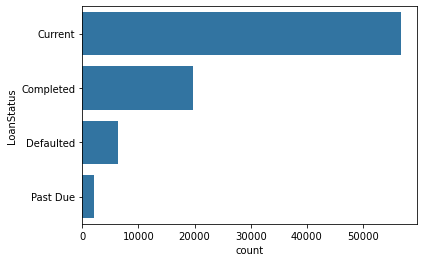

```python
#Plotting loan status
color=sns.color_palette()[0]

#Order the categorical variable
order= data.LoanStatus.value_counts().index

# Plot
sns.countplot(data=data, y='LoanStatus', order=order, color=color);
```

### Income Range

```python
data.IncomeRange.value_counts()
```

```
$50,000-74,999    25627
$25,000-49,999    24175
$100,000+         15205
$75,000-99,999    14498
$1-24,999          4654
$0                  694
Not displayed         0
Name: IncomeRange, dtype: int64
```

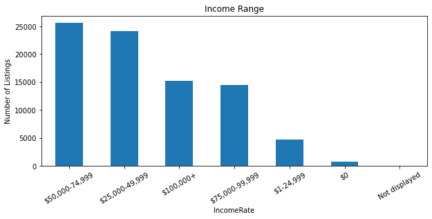

```python
#Plotting a bar graph for each income range specified

plt.figure(figsize=(10, 4))
data.IncomeRange.value_counts().plot(kind='bar', color=color);

plt.title('Income Range');
plt.xlabel('IncomeRate');
plt.ylabel('Number of Listings');

plt.xticks(rotation=30);
```

To determine the average income rate of listings, the income rate dispersion is examined. According to the plot, the majority of listings are priced at $50,000-$74,000 , then under $50,000, and so on.

### Debt to Income Ratio

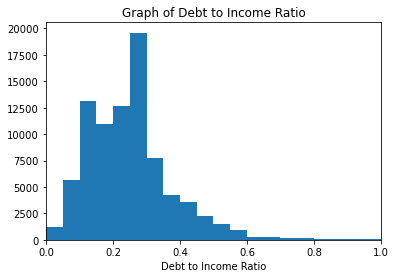

```python
#Plotting a graph of DebtToIncomeRatio
bins = 0.05
bins = np.arange(0, data['DebtToIncomeRatio'].max()+bins, bins)
plt.hist(data = data, x = 'DebtToIncomeRatio', bins = bins)
plt.title('Graph of Debt to Income Ratio')
plt.xlabel('Debt to Income Ratio')
plt.xlim(0,1);
```

```python
data[data['DebtToIncomeRatio'] > 0.8]
```

|  | LoanStatus | BorrowerAPR | EmploymentStatus | StatedMonthlyIncome | IncomeRange | DebtToIncomeRatio | LoanOriginalAmount | Term | ListingCategory | ProsperRating |
| --- | --- | --- | --- | --- | --- | --- | --- | --- | --- | --- |
| 22 | Current | 0.35356 | Other | 118.333333 | $1-24,999 | 9.20 | 4000 | 36 | Debt Consolidation | HR |
| 419 | Defaulted | 0.35356 | Other | 1061.000000 | $1-24,999 | 1.26 | 4000 | 36 | Household Expenses | HR |
| 626 | Current | 0.35797 | Employed | 3.833333 | $1-24,999 | 10.01 | 2000 | 36 | Debt Consolidation | HR |
| 627 | Completed | 0.33051 | Employed | 1666.666667 | $1-24,999 | 1.89 | 2500 | 36 | Debt Consolidation | E |
| 1326 | Defaulted | 0.35797 | Other | 2750.000000 | $25,000-49,999 | 1.19 | 4000 | 36 | Debt Consolidation | HR |
| ... | ... | ... | ... | ... | ... | ... | ... | ... | ... | ... |
| 113367 | Completed | 0.35356 | Other | 500.000000 | $1-24,999 | 2.53 | 2000 | 36 | Household Expenses | HR |
| 113387 | Completed | 0.39153 | Employed | 4000.000000 | $25,000-49,999 | 2.38 | 1500 | 36 | Other | HR |
| 113486 | Current | 0.35643 | Employed | 441.666667 | $1-24,999 | 1.05 | 2500 | 36 | Debt Consolidation | HR |
| 113625 | Defaulted | 0.35797 | Other | 1500.000000 | $1-24,999 | 0.81 | 4000 | 36 | Household Expenses | HR |
| 113718 | Current | 0.35356 | Employed | 1666.666667 | $1-24,999 | 1.16 | 4000 | 36 | Debt Consolidation | HR |

560 rows × 10 columns

Higher debt-to-income ratios generally show that someone has too much debt relative to their income. Conversely, a smaller DebtToIncomeRatio indicates a healthy ratio of income to debt. According to the aforementioned graph, the majority of loan applicants had a debt to income ratio of about 30%